# Batch effects

### Introduction

For my Advanced Biostatistics course this semester I [I gave a presentation](http://rpubs.com/erikinwest/batcheffects) about the problem of batch effects in microarray data analysis and I feel that it is worth expanding on in a post. [DNA microarrays](https://en.wikipedia.org/wiki/DNA_microarray) allow for the simultaneous measurement of thousands of genes from a cell sample. The surface of these arrays are a grid-like patchwork of *probes*, or [*oligos*](https://en.wikipedia.org/wiki/Oligonucleotide), which hybridize (i.e. bind) with copies of the cDNA made from cells. As probes are made up of a short sequence of nucleotides known to match certain genes (hence the term “oligonucleotides”) the target-probe hybridization intensity can be measured by tagging the samples with fluorescent dyes. Figure 1 below shows an example of what a DNA microarray looks like. The color intensity of the final array can be quantified, providing a numerical estimate of individual gene expression.[^1]

Figure 1: A DNA microarray under the microscope

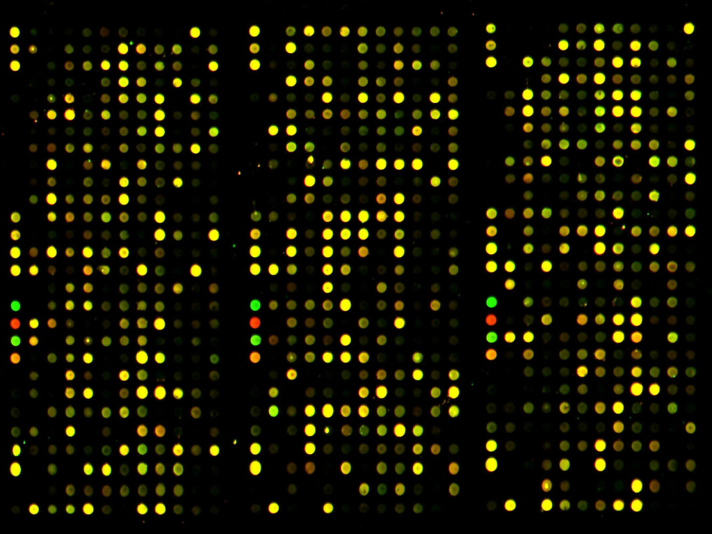

The uses of DNA microarrays in scientific research are numerous, including gene expression profiling (to help determine the etiology of diseases such as cancer) and comparative genomic hybridization (comparing the genome content for closely related organisms). To provide a toy example, we could use the sex-chromosome expression differences to determine if a cell comes from a male or female. Using the [GSE5859 data set](https://github.com/genomicsclass/GSE5859) (which will be used again later), Figure 2A shows the normalized gene expression levels for 12 individuals and 21 Y-Chromosome genes. The data suggests that the six left-hand side persons (each column is a person[^2]) are females because they have a lower-than-average expression for Y-chromosome genes. If we take the average expression values across all 208 persons which make up our sample, normalize the results, and plot the histogram, we can easily identify the gender of the individual samples (Figure 2B).

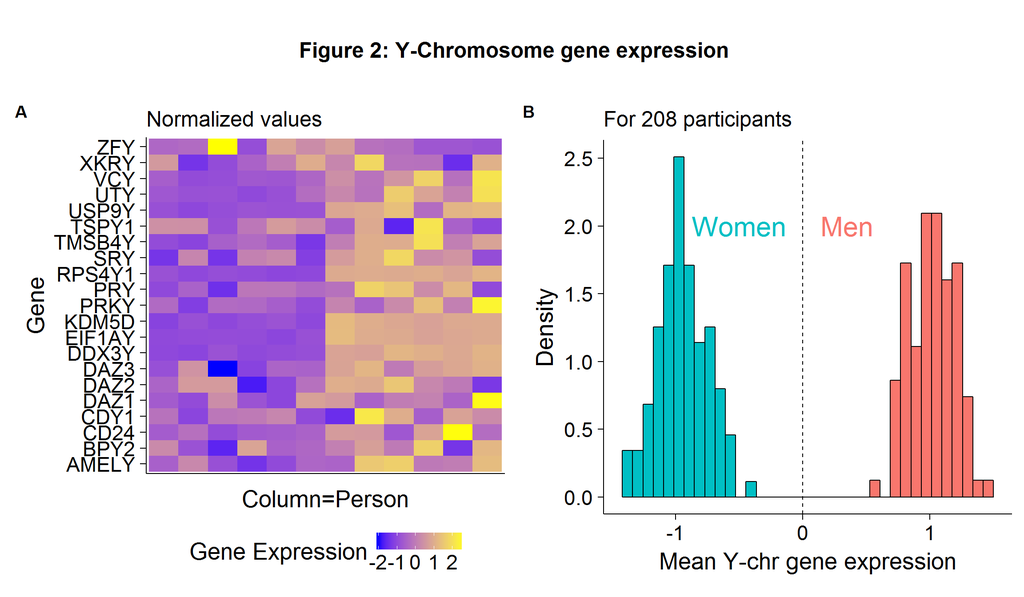